# MATH 141 Problem Type Examples

KEY

April 25, 2016

```r
library(oilabs)
library(dplyr)
library(ggplot2)
options(scipen = 99)
knitr::opts_chunk$set(warning = FALSE, fig.width = 9, fig.height = 5)
```

## Identification of Problem Types

Recall the following notation:

- $K$: categorical variable with 2 groups
- $G$: categorical variable with 3+ groups
- $H$: continuous variable

For each of the following problems,

- A. Produce the appropriate R code and generate relevant plot(s) for the sample data.
- B. Conduct the appropriate hypothesis test to solve the question of interest, assuming conditions are met.

You can assume that the significance level is 5% for all problems here.

1. The National Survey of Family Growth conducted by the Centers for Disease Control gathers information on family life, marriage and divorce, pregnancy, infertility, use of contraception, and men’s and women’s health. One of the variables collected on this survey is the age at first marriage. 5,534 randomly sampled US women between 2006 and 2010 completed the survey. The women sampled here had been married at least once. Do we have evidence that the mean age that all US women from 2006 to 2010 had an average age of first marriage of greater than 23 years?

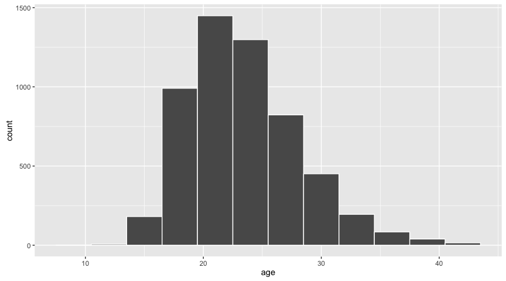

```r
ageAtMar <- read.csv("data/ageAtMar.csv")
qplot(x = age, data = ageAtMar, geom = "histogram", binwidth = 3, col = I("white"))
```

```r
inference(y = ageAtMar$age, est = "mean", null = 23, alternative = "greater",
          type = "ht", method = "theoretical", eda_plot = FALSE, inf_plot = FALSE)
```

```
## Single mean
## Summary statistics: mean = 23.4402 ;  sd = 4.7214 ;  n = 5534
## H0: mu = 23
## HA: mu > 23
## Standard error = 0.0635
## Test statistic: Z = 6.936
## p-value =  0
```

2. Average income varies from one region of the country to another, and it often reflects both lifestyles and regional living expenses. Suppose a new graduate is considering a job in two locations, Cleveland, OH and Sacramento, CA, and he wants to see whether the average income in one of these cities is higher than the other. He would like to conduct a hypothesis test based on two small samples from the 2000 Census.

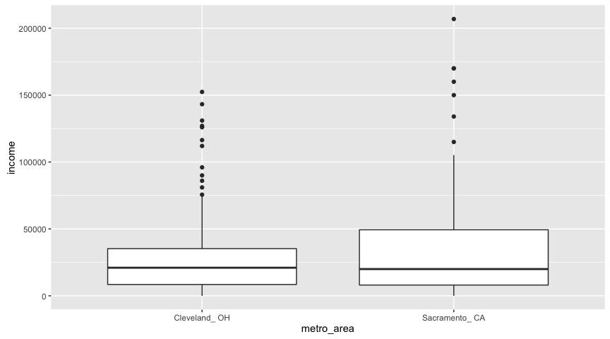

```r
cleSac <- read.delim("data/cleSac.txt", header = TRUE) %>%
  rename(metro_area = Metropolitan_area_Detailed,
         income = Total_personal_income)
qplot(x = metro_area, y = income, data = cleSac, geom = "boxplot")
```

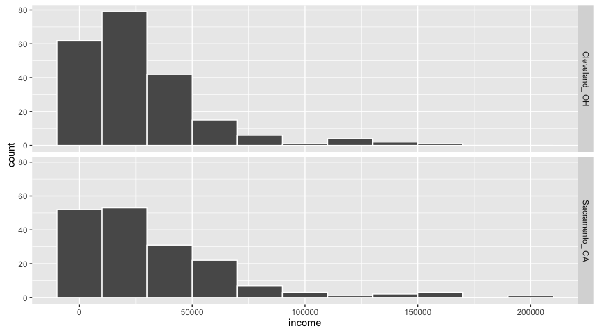

```r
qplot(x = income, data = cleSac, geom = "histogram", col = I("white"), binwidth = 20000) +
  facet_grid(metro_area ~ .)
```

```r
inference(x = cleSac$metro_area, y = cleSac$income, est = "mean", null = 0,
          alternative = "twosided", type = "ht", method = "theoretical", eda_plot = FALSE,
          inf_plot = FALSE)
```

```
## Response variable: numerical, Explanatory variable: categorical
## Difference between two means
## Summary statistics:
## n_Cleveland_ OH = 212, mean_Cleveland_ OH = 27467.07, sd_Cleveland_ OH = 27680.68
## n_Sacramento_ CA = 175, mean_Sacramento_ CA = 32427.54, sd_Sacramento_ CA = 35773.63
## Observed difference between means (Cleveland_ OH-Sacramento_ CA) = -4960.477
##
## H0: mu_Cleveland_ OH - mu_Sacramento_ CA = 0
## HA: mu_Cleveland_ OH - mu_Sacramento_ CA != 0
## Standard error = 3305.619
## Test statistic: Z =  -1.501
## p-value =  0.1334
```

3. Trace metals in drinking water affect the flavor and an unusually high concentration can pose a health hazard. Ten pairs of data were taken measuring zinc concentration in bottom water and surface water at 10 randomly selected locations on a stretch of river. Do the data suggest that the true average concentration in the bottom water exceeds that of surface water?

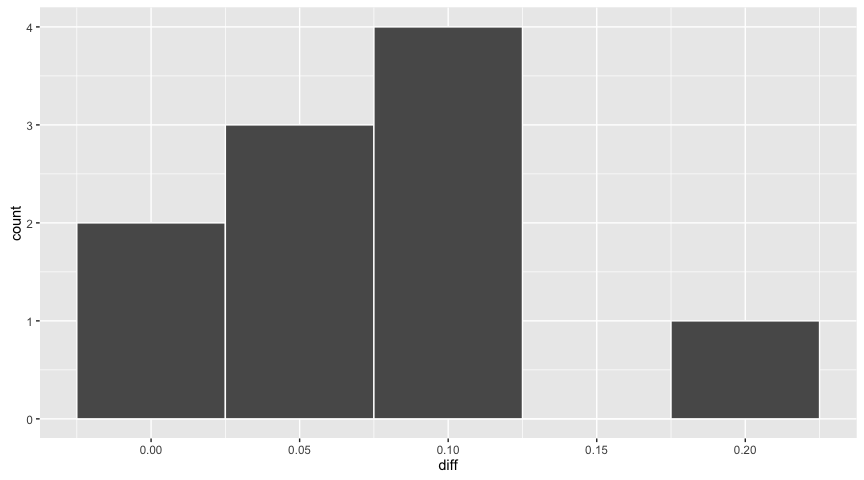

```r
zinc_conc <- read.delim("data/zinc_conc.txt", header = TRUE) %>%
  mutate(diff = bottom - surface)
qplot(x = diff, data = zinc_conc, geom = "histogram", col = I("white"), binwidth = 0.05)
```

```r
inference(y = zinc_conc$diff, est = "mean", null = 0, alternative = "greater",
          type = "ht", method = "theoretical", eda_plot = FALSE, inf_plot = FALSE)
```

```
## Single mean
## Summary statistics: mean = 0.0804 ;  sd = 0.0523 ;  n = 10
## H0: mu = 0
## HA: mu > 0
## Standard error = 0.0165
## Test statistic: T = 4.864
## Degrees of freedom:  9
## p-value =  0.0004
```

4. The Child Health and Development Studies investigate a range of topics. One study considered a random sample of pregnancies between 1960 and 1967 among women in the Kaiser Foundation Health Plan in the San Francisco East Bay area with the focus on understanding what variables tend to influence the baby’s `weight`. The variable `smoke` is coded 1 if the mother is a smoker, and 0 if not. Another variable considered is `parity`, which is 0 if the child is the first born, and 1 otherwise. Which one(s) of these variables is/are good predictor(s) of the response variable?

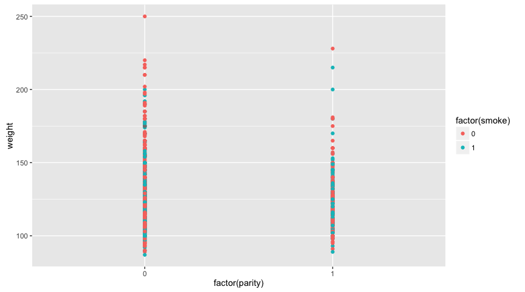

```r
babies <- read.csv("data/babies.csv")
qplot(x = factor(parity), y = weight, data = babies, color = factor(smoke), geom = "point")
```

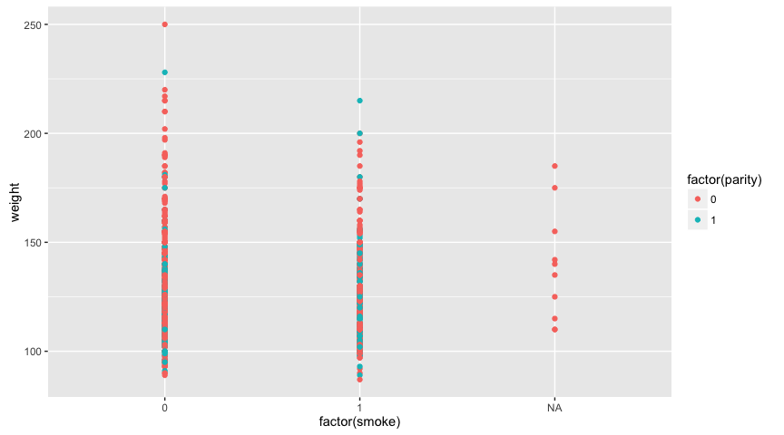

```r
qplot(x = factor(smoke), y = weight, data = babies, color = factor(parity), geom = "point")
```

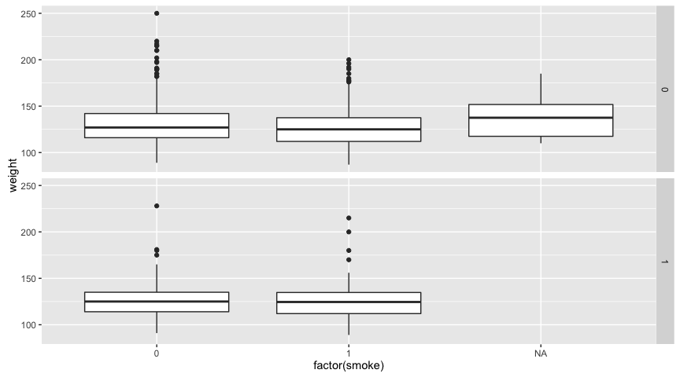

```r
qplot(x = factor(smoke), y = weight, data = babies, geom = "boxplot") +
  facet_grid(parity ~ .)
```

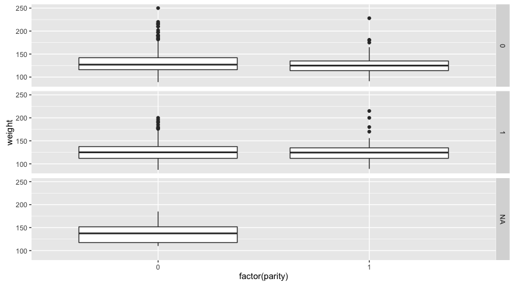

```r
qplot(x = factor(parity), y = weight, data = babies, geom = "boxplot") +
  facet_grid(smoke ~ .)
```

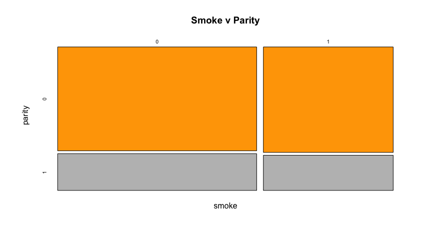

```r
mosaicplot(table(babies$smoke, babies$parity), main = "Smoke v Parity", xlab = "smoke",
           ylab = "parity", color = c("orange", "gray"))
```

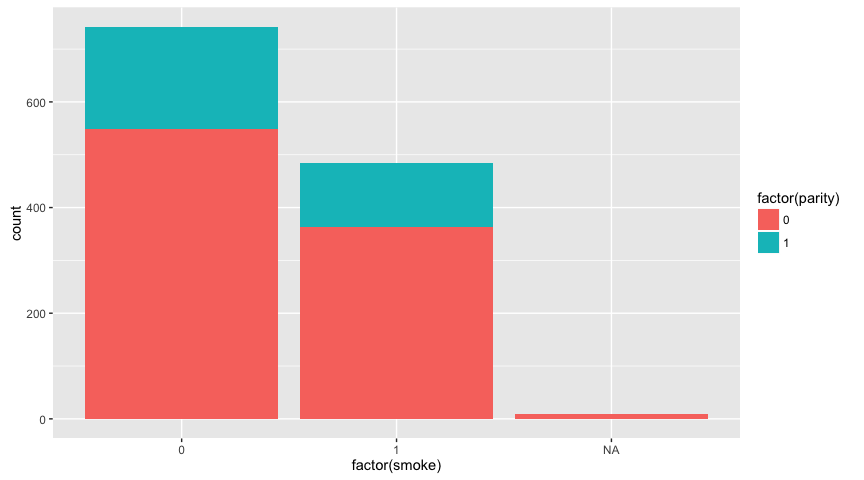

```r
qplot(x = factor(smoke), data = babies, fill = factor(parity), geom = "bar")
```

```r
babies_lm <- lm(weight ~ smoke + parity, data = babies)
summary(babies_lm)
```

```
##
## Call:
## lm(formula = weight ~ smoke + parity, data = babies)
##
## Residuals:
##     Min      1Q  Median      3Q     Max
## -41.762 -14.762  -2.762   9.238 119.238
##
## Coefficients:
##             Estimate Std. Error t value            Pr(>|t|)
## (Intercept) 130.7624     0.8547 152.996 <0.0000000000000002 ***
## smoke        -2.8649     1.2361  -2.318              0.0206 *
## parity       -4.2316     1.3727  -3.083              0.0021 **
## ---
## Signif. codes:  0 '***' 0.001 '**' 0.01 '*' 0.05 '.' 0.1 ' ' 1
##
## Residual standard error: 20.8 on 1187 degrees of freedom
##   (46 observations deleted due to missingness)
## Multiple R-squared:  0.01222,    Adjusted R-squared:  0.01055
## F-statistic:  7.34 on 2 and 1187 DF,  p-value: 0.000679
```

5. A 2010 survey asked 827 randomly sampled registered voters in California “Do you support? Or do you oppose? Drilling for oil and natural gas off the Coast of California? Or do you not know enough to say?” Conduct a hypothesis test to determine if the data provide strong evidence that the proportion of college graduates who do not have an opinion on this issue is different than that of non-college graduates.

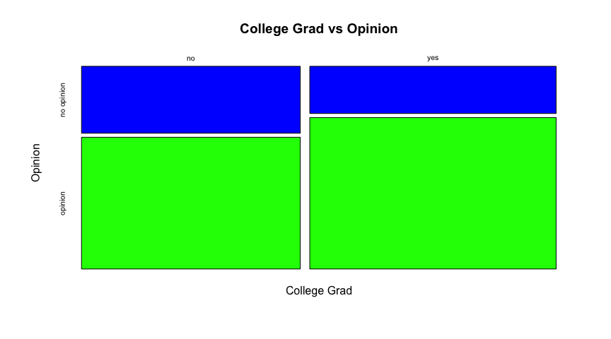

```r
offshore <- read.delim("data/offshore_drilling.txt") %>%
  mutate(response = ifelse(position == "do not know", "no opinion", "opinion")) %>%
  select(-position)
mosaicplot(table(offshore$college_grad, offshore$response),
           xlab = "College Grad",
           ylab = "Opinion",
           main = "College Grad vs Opinion",
           color = c("blue", "green"))
```

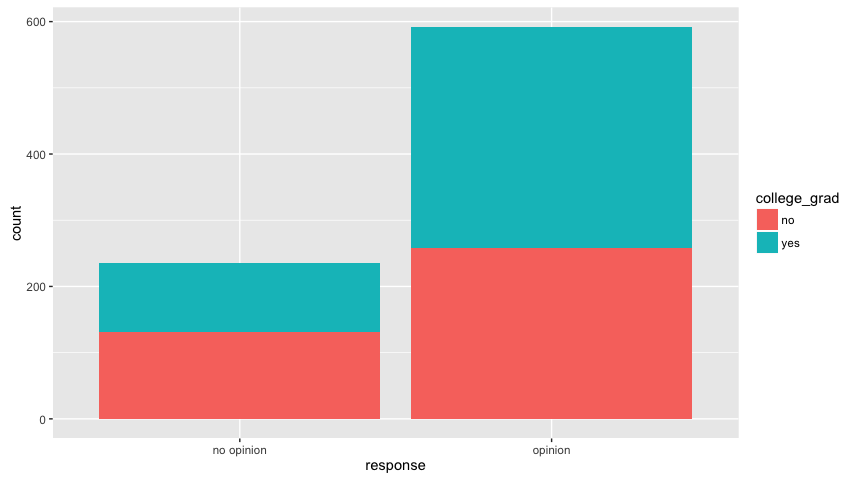

```r
qplot(x = response, data = offshore, fill = college_grad, geom = "bar")
```

```r
inference(x = offshore$college_grad, y = offshore$response,
          est = "proportion", success = "no opinion",
          alternative = "twosided", type = "ht",
          null = 0, method = "theoretical",
          eda_plot = FALSE, inf_plot = FALSE)
```

```
## Response variable: categorical, Explanatory variable: categorical
## Two categorical variables
## Difference between two proportions -- success: no opinion
## Summary statistics:
##             x
## y             no yes Sum
##   no opinion 131 104 235
##   opinion    258 334 592
##   Sum        389 438 827
## Observed difference between proportions (no-yes) = 0.0993
##
## H0: p_no - p_yes = 0
## HA: p_no - p_yes != 0
## Pooled proportion = 0.2842
## Check conditions:
##    no : number of expected successes = 111 ; number of expected failures = 278
##    yes : number of expected successes = 124 ; number of expected failures = 314
## Standard error = 0.031
## Test statistic: Z =  3.161
## p-value =  0.0016
```

6. A random sample of 500 U.S. adults were questioned regarding their political affiliation (`democrat` or `republican`) and opinion on a tax reform bill (`favor`, `indifferent`, `opposed`). Based on this sample, do we have reason to believe that political party and opinion on the bill are related?

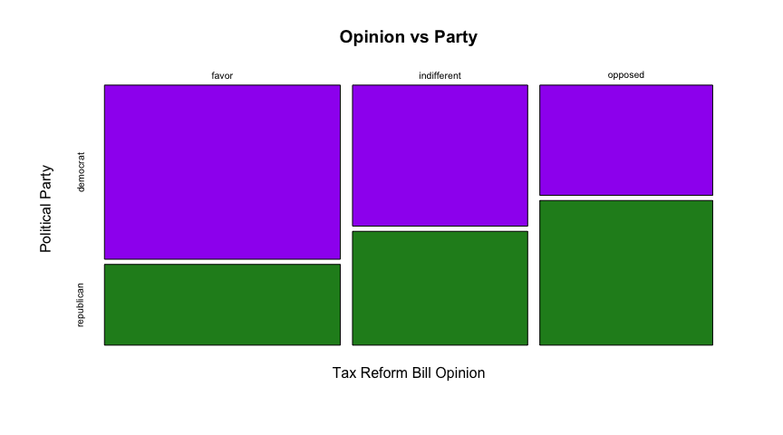

```r
tax_opinion <- read.csv("data/party_tax.csv")
mosaicplot(table(tax_opinion$opinion, tax_opinion$party),
           ylab = "Political Party",
           xlab = "Tax Reform Bill Opinion",
           main = "Opinion vs Party",
           color = c("purple", "forestgreen"))
```

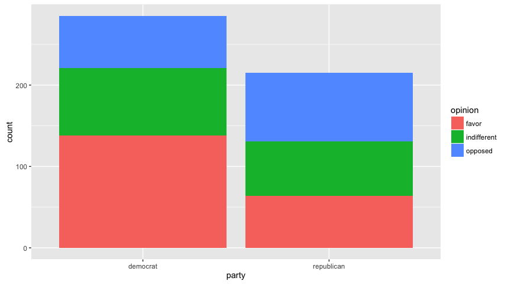

```r
qplot(x = party, data = tax_opinion, fill = opinion, geom = "bar")
```

```r
inference(x = tax_opinion$party, y = tax_opinion$opinion, est = "proportion", alternative = "greater",
          type = "ht", method = "theoretical", eda_plot = FALSE, inf_plot = FALSE)
```

```
## Response variable: categorical, Explanatory variable: categorical
## Two categorical variables
## Chi-square test of independence
##
## Summary statistics:
##              x
## y             democrat republican Sum
##   favor            138         64 202
##   indifferent       83         67 150
##   opposed           64         84 148
##   Sum              285        215 500
##
## H_0: Response and explanatory variable are independent.
## H_A: Response and explanatory variable are dependent.
## Check conditions: expected counts
##              x
## y             democrat republican
##   favor         115.14      86.86
##   indifferent    85.50      64.50
##   opposed        84.36      63.64
##
##  Pearson's Chi-squared test
##
## data:  y_table
## X-squared = 22.152, df = 2, p-value = 0.00001548
```

7. A particular brand of candy-coated chocolate comes in five different colors: brown, yellow, orange, green, and coffee. The manufacturer of the candy says the candies are distributed in the following proportions: brown - 40%, yellow - 20%, orange = 20%, and the remaining are split evenly between green and coffee. A random sample of 580 pieces of this candy are collected. Does this random sample provide evidence against the manufacturer’s claim?

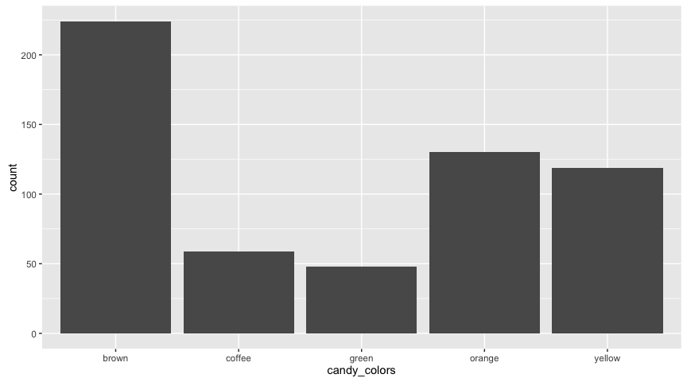

```r
candies <- read.csv("data/candies.csv")
candy_freq <- table(candies$candy_colors)
null.probs <- c(0.4, 0.1, 0.1, 0.2, 0.2)
qplot(x = candy_colors, data = candies, geom = "bar")
```

```r
chisq.test(x = candy_freq, p = null.probs)
```

```
##
##  Chi-squared test for given probabilities
##
## data:  candy_freq
## X-squared = 3.7845, df = 4, p-value = 0.436
```

8. On January 28, 1986, a routine launch was anticipated for the Challenger space shuttle. Seventy-three seconds into the flight, disaster happened: the shuttle broke apart, killing all seven crew members on board. An investigation into the cause of the disaster focused on a critical seal called an O-ring, and it is believed that damage to these O-rings during a shuttle launch may be related to the ambient temperature during the launch. Observational data on O-rings for 23 randomly selected shuttle missions was collected, where the mission order is based on the temperature at the time of the launch. `temp` gives the temperature in Fahrenheit and `damaged` is 1 when O-ring failed and 0 when it was undamaged.

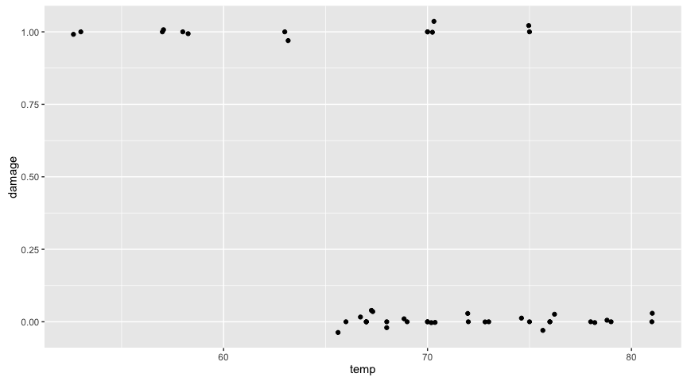

```r
orings <- read.delim("data/orings.txt", header = TRUE)
qplot(x = temp, y = damage, data = orings, geom = "point") + geom_jitter(height = 0.1)
```

```r
oring_glm <- glm(damage ~ temp, data = orings, family = binomial)
summary(oring_glm)
```

```
##
## Call:
## glm(formula = damage ~ temp, family = binomial, data = orings)
##
## Deviance Residuals:
##     Min       1Q   Median       3Q      Max
## -1.0611  -0.7613  -0.3783   0.4524   2.2175
##
## Coefficients:
##             Estimate Std. Error z value Pr(>|z|)
## (Intercept)  15.0429     7.3786   2.039   0.0415 *
## temp         -0.2322     0.1082  -2.145   0.0320 *
## ---
## Signif. codes:  0 '***' 0.001 '**' 0.01 '*' 0.05 '.' 0.1 ' ' 1
##
## (Dispersion parameter for binomial family taken to be 1)
##
##     Null deviance: 28.267  on 22  degrees of freedom
## Residual deviance: 20.315  on 21  degrees of freedom
## AIC: 24.315
##
## Number of Fisher Scoring iterations: 5
```

9. The CEO of a large electric utility claims that 80 percent of his 1,000,000 customers are satisfied with the service they receive. To test this claim, the local newspaper surveyed 100 customers, using simple random sampling. Based on these findings from the sample, can we reject the CEO’s hypothesis that 80% of the customers are satisfied?

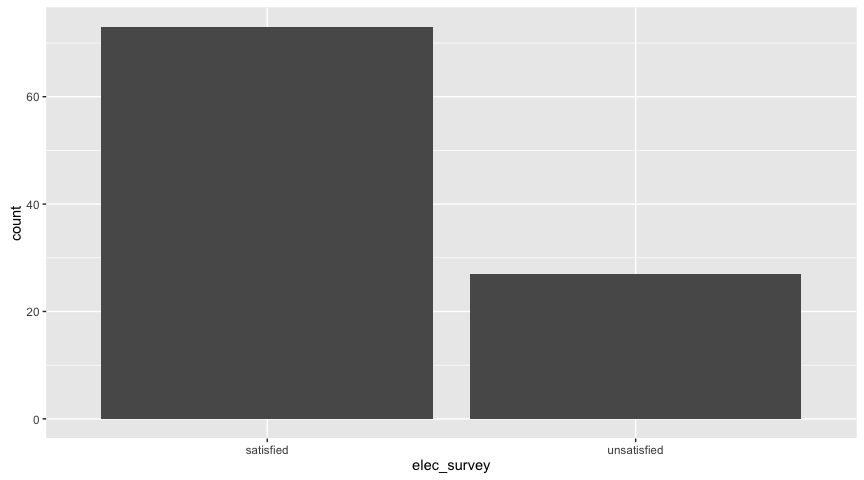

```r
elec_survey <- c(rep("satisfied", 73), rep("unsatisfied", 27))
qplot(x = elec_survey, geom = "bar")
```

```r
inference(y = elec_survey, est = "proportion", null = 0.8,
  success = "satisfied", type = "ht",
  alternative = "twosided", method = "theoretical",
  eda_plot = FALSE, inf_plot = FALSE)
```

```
## Single proportion -- success: satisfied
## Summary statistics: p_hat = 0.73 ;  n = 100
## H0: p = 0.8
## HA: p != 0.8
## Check conditions: number of expected successes = 80 ; number of expected failures = 20
## Standard error = 0.04
## Test statistic: Z =  -1.75
## p-value =  0.0802
```

10. Chicken farming is a multi-billion dollar industry, and any methods that increase the growth rate of young chicks can reduce consumer costs while increasing company profits, possibly by millions of dollars. An experiment was conducted to measure and compare the effectiveness of various feed supplements on the growth rate of chickens. Newly hatched chicks were randomly allocated into six groups, and each group was given a different feed supplement. Do these data provide strong evidence that the average weights of chickens that were fed linseed and horsebean are different?

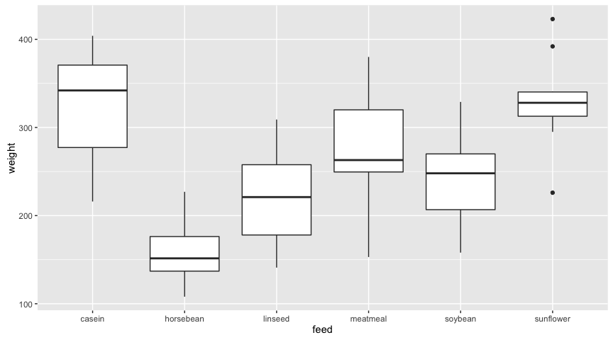

```r
chick_wts <- read.csv("data/chickwts.csv")
qplot(x = feed, y = weight, data = chick_wts, geom = "boxplot")
```

```r
inference(x = chick_wts$feed, y = chick_wts$weight, est = "mean",
  type = "ht", alternative = "greater", method = "theoretical",
  eda_plot = FALSE, inf_plot = FALSE)
```

```
## Response variable: numerical, Explanatory variable: categorical
## ANOVA
##
## Summary statistics:
## n_casein = 12, mean_casein = 323.5833, sd_casein = 64.4338
## n_horsebean = 10, mean_horsebean = 160.2, sd_horsebean = 38.6258
## n_linseed = 12, mean_linseed = 218.75, sd_linseed = 52.2357
## n_meatmeal = 11, mean_meatmeal = 276.9091, sd_meatmeal = 64.9006
## n_soybean = 14, mean_soybean = 246.4286, sd_soybean = 54.1291
## n_sunflower = 12, mean_sunflower = 328.9167, sd_sunflower = 48.8364
##
## H_0: All means are equal.
## H_A: At least one mean is different.
## Analysis of Variance Table
##
## Response: y
##           Df Sum Sq Mean Sq F value          Pr(>F)
## x          5 231129   46226  15.365 0.0000000005936
## Residuals 65 195556    3009
##
## Pairwise tests: t tests with pooled SD
##           casein horsebean linseed meatmeal soybean
## horsebean 0.0000        NA      NA       NA      NA
## linseed   0.0000    0.0152      NA       NA      NA
## meatmeal  0.0456    0.0000  0.0135       NA      NA
## soybean   0.0007    0.0003  0.2041   0.1726      NA
## sunflower 0.8125    0.0000  0.0000   0.0264  0.0003
```